# Bayes Workshop Week 2a

```r
library("rstan")
library("loo")
library("bridgesampling")
```

# Pareto-smoothing importance sampling leave-one-out cross-validation (PSIS)

In this side note, we will implement PSIS, an approximation of leave-one-out cross-validation using posterior samples. I will follow the procedure of [Vehtari, Gelman, & Gabry (2017)](https://link.springer.com/article/10.1007/s11222-016-9696-4) (also see McElreath, 2020).

## Model fitting

Let’s first fit the two mean-comparison models. For convenience, make sure to evaluate the log point-wise predictive density in the `generated quantities` block.

```r
# Simulate a dataset
set.seed(1)
y1 = rnorm(100, 10, 0.5)
y2 = rnorm(100, 15, 1)
set.seed(NULL)

y.range = range(c(y1, y2))

# Plot!
hist(y1, breaks = seq(y.range[1], y.range[2], length.out = 25), col = rgb(1,0,0,0.3),
     xlim = c(8, 18), main = "Data", xlab = "Values")
hist(y2, breaks = seq(y.range[1], y.range[2], length.out = 25), col = rgb(0,0,1,0.3), add = T)
```

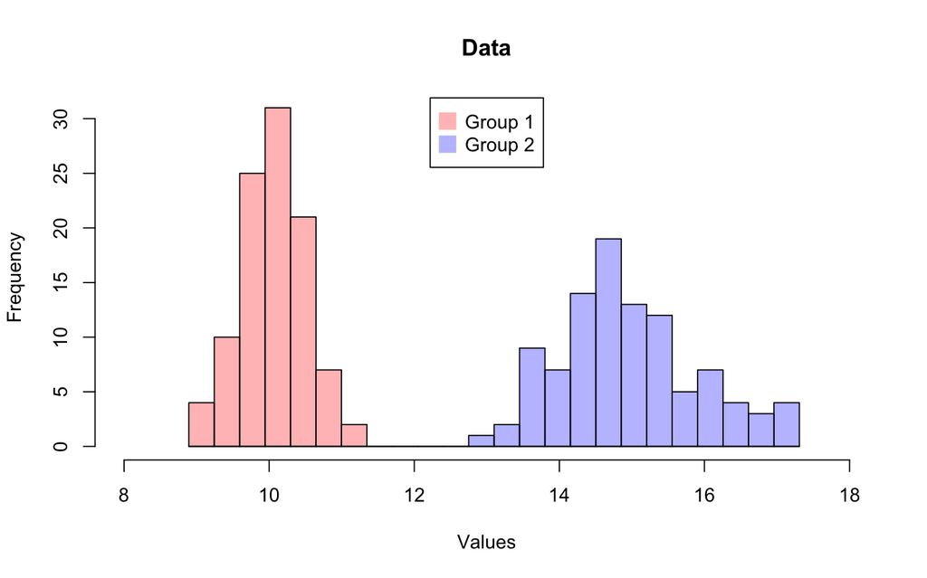

```r
legend(inset = 0.01, "top", col = c(rgb(1,0,0,0.3), rgb(0,0,1,0.3)),
       pch = 15, pt.cex = 2, c("Group 1", "Group 2"))
```

```r
m1.statement = "
data {
  int n;
  real y1[n]; // y1 is a real-numbered vector of length n.
  real y2[n]; // y2 is a real-numbered vector of length n.
}

parameters {
  vector[2] mu;
  real sigma;
}

model {
  for (i in 1:n){
    y1[i] ~ normal(mu[1], sigma);
    y2[i] ~ normal(mu[2], sigma);
  }
  for (j in 1:2){
    mu[j] ~ normal(0, 10);
  }
  sigma ~ exponential(1);
}

generated quantities {
  // Declare a variable storing log pointwise predictive density.
  // The first n elements will be for Group 1 (corresponding to y1),
  // and the second n elements for Group 2 (corresponding to y2).
  vector[2*n] log_lik;

  // The following lines evaluate the probability
  // that each data point is observed given the posterior samples of mu and sigma.
  for (i in 1:n){
    log_lik[i] = normal_lpdf(y1[i] | mu[1], sigma);
    log_lik[i+n] = normal_lpdf(y2[i] | mu[2], sigma);
  }
}
"

model1 = stan_model(model_code = m1.statement)
fit1 = sampling(model1,
                data = list(n = length(y1), y1 = y1, y2 = y2),
                iter = 2000,
                chains = 4, cores = 4)
```

```r
m2.statement = "
data {
  int n;
  real y1[n]; // y1 is a real-numbered vector of length n.
  real y2[n]; // y2 is a real-numbered vector of length n.
}

parameters {
  vector[2] mu;
  vector[2] sigma;
}

model {
  for (i in 1:n){
    y1[i] ~ normal(mu[1], sigma[1]);
    y2[i] ~ normal(mu[2], sigma[2]);
  }
  for (j in 1:2){
    mu[j] ~ normal(0, 10);
  }
  sigma ~ exponential(1);
}

generated quantities {
  vector[2*n] log_lik;
  for (i in 1:n){
    log_lik[i] = normal_lpdf(y1[i] | mu[1], sigma[1]);
    log_lik[i+n] = normal_lpdf(y2[i] | mu[2], sigma[2]);
  }
}
"

model2 = stan_model(model_code = m2.statement)
fit2 = sampling(model2,
                data = list(n = length(y1), y1 = y1, y2 = y2),
                iter = 2000,
                chains = 4, cores = 4)
```

## Importance sampling

As discussed in the main note, we want to evaluate the expected predictive density (epd) for the $i$-th data point, $y_i$, using the posterior obtained from the dataset without the ‘held-out sample’, $\mathbf{y}_{-i} = \{y_1, y_2, \cdots, y_{i-1}, y_{i+1}, \cdots, y_N\}$.
$$\text{epd}_i = \int_{\theta\in\Theta}p(y_i |
\theta) p(\theta | \mathbf{y}_{-i}) d\theta$$
However, this is very costly when the number of data points $N$ is large.

The importance sampling method suggests an alternative approach using a so-called ‘proposal distribution’ $g$ that can replace the target distribution $p(\cdot | \mathbf{y}_{-i})$ that we cannot get:
$$\begin{align}\text{epd}_i &=
\int_{\theta\in\Theta}p(y_i | \theta) p(\theta | \mathbf{y}_{-i})
d\theta \\
&=\int_{\theta\in\Theta}p(y_i | \theta) \frac{p(\theta |
\mathbf{y}_{-i})}{g(\theta)} g(\theta) d\theta .\end{align}$$
Going even further,
$$\begin{align}\text{epd}_i &=
\frac{\int_{\theta\in\Theta}p(y_i | \theta) p(\theta | \mathbf{y}_{-i})
d\theta}{\int_{\theta\in\Theta} p(\theta | \mathbf{y}_{-i}) d\theta}
\qquad \Bigg(\because \int_{\theta\in\Theta} p(\theta | \mathbf{y}_{-i})
d\theta = 1\Bigg)\\
&=\frac{\int_{\theta\in\Theta}p(y_i | \theta) \frac{p(\theta |
\mathbf{y}_{-i})}{g(\theta)} g(\theta) d\theta}{\int_{\theta\in\Theta}
\frac{p(\theta | \mathbf{y}_{-i})}{g(\theta)}g(\theta) d\theta}
.\end{align}$$

The most convenient option for $g$ is the posterior obtained from the complete dataset, $p(\theta | \mathbf{y})$:
$$\begin{align}\text{epd}_i
&=\frac{\int_{\theta\in\Theta}p(y_i | \theta) \frac{p(\theta |
\mathbf{y}_{-i})}{p(\theta | \mathbf{y})} p(\theta | \mathbf{y})
d\theta}{\int_{\theta\in\Theta} \frac{p(\theta |
\mathbf{y}_{-i})}{p(\theta | \mathbf{y})}p(\theta | \mathbf{y}) d\theta}
.\end{align}$$
The ratio $p(\theta | \mathbf{y}_{-i})/p(\theta | \mathbf{y})$ is called an **importance ratio** and plays a crucial role in importance sampling. The ‘calibration’ we need by using an alternative proposal distribution is done by this importance ration.

The problem is that we don’t know $p(\theta | \mathbf{y}_{-i})$, but we can still compute this ratio somehow. See below:
$$\begin{align}p(\theta | \mathbf{y}) &\propto
p(\theta) p(\mathbf{y}|\theta) = p(\theta)\prod_j p(y_j | \theta),\\
p(\theta | \mathbf{y}_{-i}) &\propto p(\theta)
p(\mathbf{y}_{-i}|\theta) = p(\theta)\prod_{j \neq i} p(y_j | \theta),\\
\frac{p(\theta | \mathbf{y}_{-i})}{p(\theta | \mathbf{y})} &\propto
\frac{p(\theta)\prod_{j \neq i} p(y_j | \theta)}{p(\theta)\prod_j p(y_j
| \theta)} = \frac{1}{p(y_i | \theta)}.\end{align}$$
The importance ratio we want is the inverse of the posterior predictive density for the held-out sample $y_i$ estimated from the complete dataset.

Therefore,
$$\begin{align}\text{epd}_i
&=\frac{\int_{\theta\in\Theta}p(y_i | \theta) \frac{p(\theta |
\mathbf{y}_{-i})}{p(\theta | \mathbf{y})} p(\theta | \mathbf{y})
d\theta}{\int_{\theta\in\Theta} \frac{p(\theta |
\mathbf{y}_{-i})}{p(\theta | \mathbf{y})}p(\theta | \mathbf{y}) d\theta}
\\
&=\frac{\int_{\theta\in\Theta}p(y_i | \theta) \frac{1}{p(y_i |
\theta)} p(\theta | \mathbf{y}) d\theta}{\int_{\theta\in\Theta}
\frac{1}{p(y_i | \theta)}p(\theta | \mathbf{y}) d\theta} \\
&= \frac{\int_{\theta\in\Theta}p(\theta | \mathbf{y})
d\theta}{\int_{\theta\in\Theta} \frac{1}{p(y_i | \theta)}p(\theta |
\mathbf{y}) d\theta} \\
&= \frac{1}{\int_{\theta\in\Theta} \frac{1}{p(y_i | \theta)}p(\theta
| \mathbf{y}) d\theta}.\end{align}$$

## Pareto smoothing

It turned out that we can just average the importance ratio (i.e., the inverse of the point-wise predictive density). However, some posterir samples may produce the predictive density that is extremely low, making its inverse explosively large. This may harm the reliability of the epd estimate.

Vehtari et al. (2017) suggests a smoothing procedure using a generalized Pareto distribution with pdf
$$f_{gP}(x | \mu, \sigma, k) = \frac{1}{\sigma}
\bigg[1 + k \big(\frac{x -
\mu}{\sigma}\big)\bigg]^{-\frac{1}{k}-1}.$$

1. Given the held-out sample $y_i$, fit the generalized Pareto distribution to the top 20% largest importance ratio, denoted $\{r_{i,1}^*, r_{i,2}^*, \cdots, r_{i,M}^*\}$. $M$ is the total number of the chosen largest importance ratio (i.e., $M = 0.2 S$). You will get an estimate of the location parameter $\hat{\mu}$, the scale parameter $\hat{\sigma}$, and the shape parameter $\hat{k}$.
2. Using the estimates $(\hat{\mu}, \hat{\sigma}, \hat{k})$, stabilize the $M$ largest importance ratio by
   $$\tilde{w}_{i,s} = F_{gP}^{-1}
   \bigg(\frac{\text{rank}(r_{i,s}^*) - 0.5}{M}\bigg | \hat{\mu},
   \hat{\sigma}, \hat{k} \bigg)$$
   where
   $$F_{gP}^{-1}(p | \mu, \sigma, k) = \mu +
   \frac{\sigma}{k} \bigg\{\bigg(\frac{1}{1-p}\bigg)^{k} -1\bigg\}$$
   is an inverse function of the generalized Pareto CDF, and $\text{rank}(x)$ returns the rank of $x$ in a set of consideration.
3. If $r_{i,s}$ was smoothed, replace it with $\tilde{w}_{i,s}$. Let’s denote the updated importance ratio vector $\tilde{\mathbf{r}}_{i}$.
4. To make sure that the final estimate has finite variance, truncate $\tilde{\mathbf{r}}_i$ at $S^{3/4} \frac{1}{M} \sum_{j=1}^M\tilde{w}_{i,j}$. Let’s denote the truncated importance ratio $w_{i,s}$.

Then, for the held-out sample $y_i$, its approximate expected predictive density is
$$\text{epd}_i =
\frac{\sum_{s=1}^S w_{i,s} p(y_i | \hat{\theta}_s)}{\sum_{s=1}^S
w_{i,s}}.$$
Our target measure, the expected log point-wise predictive density is
$$\text{elpd}_{\text{PSIS}} = \sum_{i=1}^{N} \log
(\text{epd}_i) = \sum_{i=1}^N \log \Bigg\{\frac{\sum_{s=1}^S w_{i,s}
p(y_i | \hat{\theta}_s)}{\sum_{s=1}^S w_{i,s}}\Bigg\}.$$

# Line-by-line implementation

First, we need a few custom functions.

```r
# Custom functions required for fitting the generalized Pareto distribution

# 1. softplus for estimating sigma.
softplus = function(x, beta = 10){
  log(1+exp(beta * x)) / beta
}

# 2. log density of the generaliezd Pareto distribution
log.dens.gpd = function(prmts, dat){
  mu = prmts[1]
  sigma = softplus(prmts[2]) # transform to make it positive
  k = prmts[3]

  z = (dat - mu) / sigma

  dens = (1/sigma) * (1 + k * z)^(-1/k -1)
  sum(log(dens))
}

# 3. Inverse CDF of the generaliezd Pareto distribution
inv.cdf.gpd = function(p, prmts.optim){
  mu = prmts.optim[1]
  sigma = softplus(prmts.optim[2]) # transform to make it positive
  k = prmts.optim[3]

  mu + sigma/k * ((1/(1-p))^k - 1)
}
```

Let’s extract the log point-wise predictive density values, stored in the `log_lik` variable.

```r
loglik1 = extract(fit1)$log_lik
loglik2 = extract(fit2)$log_lik

# Importance ratio = 1/exp(log_lik)
IR1 = 1/exp(loglik1)
IR2 = 1/exp(loglik2)

# Identify the top 20% largest importance ratios
idx.extreme.IR1 = which(IR1 > quantile(IR1, probs = 0.8), arr.ind = T)
idx.extreme.IR2 = which(IR2 > quantile(IR2, probs = 0.8), arr.ind = T)

extreme.IR1 = IR1[idx.extreme.IR1]
extreme.IR2 = IR1[idx.extreme.IR2]
```

Fit the generalized Pareto distribution to extreme importance ratio values. We will simply optimize (`optim`) the log density function (`log.dens.gpd`) to find the parameters that maximize the likelihood.

```r
gpd.optim1 = optim(runif(3, 0, 1), log.dens.gpd, dat = extreme.IR1,
                   control = list(maxit = 10000, fnscale = -1))
gpd.optim2 = optim(runif(3, 0, 1), log.dens.gpd, dat = extreme.IR2,
                   control = list(maxit = 10000, fnscale = -1))
```

- `optim` is R’s default optimizer function. By default, `optim` finds a parameter that minimizes the output of a target function (`log.dens.gpd`).
- `control = list(...)` is an argument for controlling the optimizer’s behavior.
  - `fnscale`: The function `optim` is by default a minimizer, but we want to find the parameter maximizing the log density (i.e., `log.dens.gpd`). By setting `fnscale` as any negative value, you can make `optim` work as a maximizer.

Stabilize the extreme importance ratio values. The inverse CDF function (`inv.cdf.gpd`) was defined to use the estimate from the optimizer (`optim`) directly. You can retrieve the estimated best parameter by calling `(optim_output)$par`.

```r
# Stabilize the extreme importance ratios
stabilized.IR1 = inv.cdf.gpd((rank(extreme.IR1) - 0.5)/length(extreme.IR1), gpd.optim1$par)
stabilized.IR2 = inv.cdf.gpd((rank(extreme.IR2) - 0.5)/length(extreme.IR2), gpd.optim2$par)

# Replace the extreme importance ratios with the smoothed values
IR1.new = IR1; IR1.new[idx.extreme.IR1] = stabilized.IR1
IR2.new = IR2; IR2.new[idx.extreme.IR2] = stabilized.IR2
```

Truncate the updated importance ratio:

```r
for (i in 1:ncol(IR1.new)){
  temp.ub = length(IR1.new[,i])^(3/4) * mean(IR1.new[,i])
  IR1.new[,i] = unlist(sapply(IR1.new[,i], function(x) ifelse(x > temp.ub, temp.ub, x)))
}

for (i in 1:ncol(IR2.new)){
  temp.ub = length(IR2.new[,i])^(3/4) * mean(IR2.new[,i])
  IR2.new[,i] = unlist(sapply(IR2.new[,i], function(x) ifelse(x > temp.ub, temp.ub, x)))
}
```

Our target measure, the expected log predictive density, can be computed as follows:

```r
# The elpd estimate
elpd1 = sum(log(colSums(IR1.new * exp(loglik1)) / colSums(IR1.new)))
elpd2 = sum(log(colSums(IR2.new * exp(loglik2)) / colSums(IR2.new)))

# The standard error of the elpd estimate
elpd1.se = sqrt(ncol(post1$log_lik) * var(log(colSums(IR1.new * exp(loglik1)) / colSums(IR1.new))))
elpd2.se = sqrt(ncol(post2$log_lik) * var(log(colSums(IR2.new * exp(loglik2)) / colSums(IR2.new))))
```

Let’s compare our implementation with the output from `loo`:

```r
loo1 = loo(fit1)
loo2 = loo(fit2)

# Compare
plot(1:2-0.05, c(loo1$estimates[1,1], loo2$estimates[1,1]), pch = 16, cex = 2, col = "red",
     xlim = c(0.5, 2.5), ylim = c(-260, -175),
     xaxt="n", xlab = "", ylab = "Log density",
     main = "Expected log predictive density")
lines(c(1,1)-0.05,
      c(loo1$estimates[1,1] - loo1$estimates[1,2], loo1$estimates[1,1] + loo1$estimates[1,2]),
      col = "red")
```

```r
lines(c(2,2)-0.05,
      c(loo2$estimates[1,1] - loo2$estimates[1,2], loo2$estimates[1,1] + loo2$estimates[1,2]),
      col = "red")
axis(1, at = 1:2, c("Model 1", "Model 2"))
```

```r
points(1:2 + 0.05, c(elpd1, elpd2), pch = 15, cex = 2, col = "blue")
lines(c(1,1)+0.05,
      c(elpd1 - elpd1.se, elpd1 + elpd1.se),
      col = "blue")
```

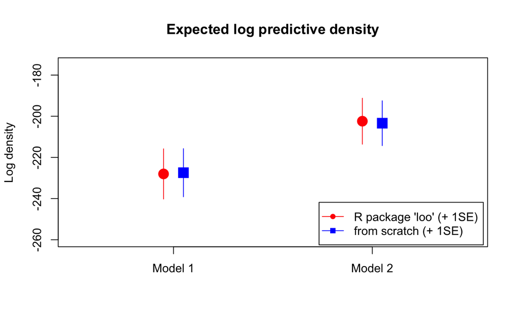

```r
lines(c(2,2)+0.05,
      c(elpd2 - elpd2.se, elpd2 + elpd2.se),
      col = "blue")

legend(inset = 0.01, "bottomright",
       pch = c(16, 15), lwd = 1, lty = 1, col = c("red", "blue"),
       c("R package 'loo' (+ 1SE)", "from scratch (+ 1SE)"))
```

# Self-contained function

The PSIS procedure implemented in this note is unstable because I handled the step of fitting a Pareto distribution naively. (This function is also very slow!) Please just use `loo`.

```r
psis.looci = function(stanfit_object, par = "log_lik"){
  # Compute the importance ratio
  loglik = extract(stanfit_object)[[par]]
  IR = 1/exp(loglik)

  # Identify the extreme IRs.
  idx.extreme.IR = which(IR > quantile(IR, probs = 0.8), arr.ind = T)
  extreme.IR = IR[idx.extreme.IR]

  # Fit the generalized Pareto distribution to the extreme IRs.
  gpd.optim = optim(runif(3, -0.5, 0.5), log.dens.gpd, dat = extreme.IR,
                    control = list(maxit = 10000, fnscale = -1))

  # Stabilize and update IRs.
  stabilized.IR = inv.cdf.gpd((rank(extreme.IR) - 0.5)/length(extreme.IR), gpd.optim$par)
  IR.new = IR
  IR.new[idx.extreme.IR] = stabilized.IR

  # Truncate the updated IRs.
  temp.ub = sapply(1:ncol(IR.new), function(i) IR.new[,i]^(3/4) * mean(IR.new[,i]))
  for (i in 1:ncol(IR.new)){
    IR.new[,i] = unlist(sapply(IR.new[,i], function(x) ifelse(x > temp.ub[i], temp.ub[i], x)))
  }

  # Output
  elpd = sum(log(colSums(IR.new * exp(loglik)) / colSums(IR.new)))
  elpd.se = sqrt(ncol(loglik) * var(log(colSums(IR.new * exp(loglik)) / colSums(IR.new))))
  looci = -2 * elpd
  looci.se = 2 * elpd.se

  out = c(elpd, elpd.se, looci, looci.se, gpd.optim$par[3])
  names(out) = c("elpd", "elpd_se", "looci", "looci_se", "pareto_k")
  out
}
```

```r
psis1 = psis.looci(fit1)
print(psis1)
```

```
         elpd       elpd_se         looci      looci_se      pareto_k
-2.253143e+02  1.165600e+01  4.506287e+02  2.331200e+01  7.151783e-03
```

```r
print(loo(fit1))
```

```
Computed from 4000 by 200 log-likelihood matrix
```

|  | Estimate | SE |
| --- | --- | --- |
| elpd_loo | -228.0 | 12.2 |
| p_loo | 3.4 | 0.5 |
| looic | 456.1 | 24.4 |

```
------
Monte Carlo SE of elpd_loo is 0.0.

All Pareto k estimates are good (k < 0.5).
See help('pareto-k-diagnostic') for details.
```